# **Лабораторна робота № 2**

## **Тема. Налаштування Python/DS середовищ (Miniconda + Positron)**

## **Мета:** Сформувати правильну ментальну модель роботи з Python-середовищами та навчитися будувати відтворюване, кероване і масштабоване середовище для загальних python-проєктів та Data Science і Machine Learning.

## **Виконав:** Гордієнко В.Ю.

### **Порядок виконання роботи**

1. Видалено або відключено системний Python (WindowsApps alias).
2. Встановлено Miniconda без додавання до PATH.
3. Налаштовано канали:  
   • додано conda-forge  
   • увімкнено strict channel priority
4. Створено базові середовища:  
   • py311 (Python 3.11)  
   • py312 (Python 3.12)
5. Створено базові шаблонні середовища:  
   • ds-base-2026.1 (для Data Science)  
   • py-dev-base (для розробки)
6. Створено проєктне середовище:  
   • asd (клон від ds-base-2026.1)
7. Зареєстровано kernel через ipykernel.
8. Підключено середовище в Positron та перевірено через sys.executable.
9. Збережено середовище у файл environment.yml.

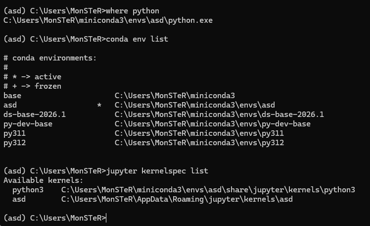

## **Висновок:** після виконання лабораторної роботи я сформував правильну ментальну модель роботи з Python-середовищами та навчився будувати відтворюване, кероване і масштабоване середовище для загальних python-проєктів та Data Science і Machine Learning.

### **Контрольні питання:**

1. Чому не рекомендується використовувати системний Python у Windows?

Щоб не пошкодити роботу операційної системи та уникнути конфліктів, коли ваші проєкти вимагають різних версій бібліотек, ніж ті, що потрібні самій Windows.

2. Навіщо створювати окреме середовище для кожного проєкту?

Для ізоляції. Це дозволяє встановлювати різні версії пакетів для різних проєктів, щоб вони не заважали один одному.

3. У чому різниця між базовим середовищем і проєктним?

base — це основне середовище Anaconda (його краще залишати чистим), а проєктне — це окрема «кімната» під конкретну роботу, яку можна легко видалити або змінити.

4. Для чого використовується environment.yml?

Він дозволяє швидко відтворити всі необхідні бібліотеки та їх версії на іншому комп'ютері.

5. Як перевірити, який Python використовується в ноутбуці?

Виконати команду where python